# Project: Investigate No Show Appointments Dataset

- Introduction
- Data Wrangling
- Exploratory Data Analysis
- Conclusions

## Introduction

##### *This dataset collects information from 100k medical appointments in Brazil and is focused on the question of whether or not patients show up for their appointment. A number of characteristics about the patient are included in each row.*

### Columns description:

> **PatientId** - Identification of a patient.  
> **AppointmentID** - Identification of each appointment.  
> **Gender** - Male or Female.  
> **DataMarcacaoConsulta** - The day of the actuall appointment.  
> **DataAgendamento** - The day someone called or registered the appointment.  
> **Age** - How old is the patient.  
> **Neighbourhood** - Where the appointment takes place.  
> **Scholarship** - Ture of False.  
> **Hipertension** - True or False.  
> **Diabetes** - True or False.  
> **Alcoholism** - True or False.  
> **Handcap** - True or False.  
> **SMS_received** - received SMS remainder or not.  
> **No-show** - True or False.

#### Research Questions

1\ What is the overall appointment **show-up vs. no show-up percentage?**  
2\ Did SMS reminders messages decrease the **proportion of appointment not show up?**

```python
#Importing the libraries needed

import pandas as pd
import numpy as np
import matplotlib.pyplot as plt
import seaborn as sns
% matplotlib inline
```

```python
#to load the dataset and print out first five lines.

df = pd.read_csv('no_show_app.csv')
df.head()
```

|  | PatientId | AppointmentID | Gender | ScheduledDay | AppointmentDay | Age | Neighbourhood | Scholarship | Hipertension | Diabetes | Alcoholism | Handcap | SMS_received | No-show |
| --- | --- | --- | --- | --- | --- | --- | --- | --- | --- | --- | --- | --- | --- | --- |
| 0 | 2.987250e+13 | 5642903 | F | 2016-04-29T18:38:08Z | 2016-04-29T00:00:00Z | 62 | JARDIM DA PENHA | 0 | 1 | 0 | 0 | 0 | 0 | No |
| 1 | 5.589978e+14 | 5642503 | M | 2016-04-29T16:08:27Z | 2016-04-29T00:00:00Z | 56 | JARDIM DA PENHA | 0 | 0 | 0 | 0 | 0 | 0 | No |
| 2 | 4.262962e+12 | 5642549 | F | 2016-04-29T16:19:04Z | 2016-04-29T00:00:00Z | 62 | MATA DA PRAIA | 0 | 0 | 0 | 0 | 0 | 0 | No |
| 3 | 8.679512e+11 | 5642828 | F | 2016-04-29T17:29:31Z | 2016-04-29T00:00:00Z | 8 | PONTAL DE CAMBURI | 0 | 0 | 0 | 0 | 0 | 0 | No |
| 4 | 8.841186e+12 | 5642494 | F | 2016-04-29T16:07:23Z | 2016-04-29T00:00:00Z | 56 | JARDIM DA PENHA | 0 | 1 | 1 | 0 | 0 | 0 | No |

## Data Wrangling

### General Properties

```python
#To find the datafram's size

df.shape
```

```
(110527, 14)
```

```python
#Getting descriptive statistics for all columns

df.describe()
```

|  | PatientId | AppointmentID | Age | Scholarship | Hipertension | Diabetes | Alcoholism | Handcap | SMS_received |
| --- | --- | --- | --- | --- | --- | --- | --- | --- | --- |
| count | 1.105270e+05 | 1.105270e+05 | 110527.000000 | 110527.000000 | 110527.000000 | 110527.000000 | 110527.000000 | 110527.000000 | 110527.000000 |
| mean | 1.474963e+14 | 5.675305e+06 | 37.088874 | 0.098266 | 0.197246 | 0.071865 | 0.030400 | 0.022248 | 0.321026 |
| std | 2.560949e+14 | 7.129575e+04 | 23.110205 | 0.297675 | 0.397921 | 0.258265 | 0.171686 | 0.161543 | 0.466873 |
| min | 3.921784e+04 | 5.030230e+06 | -1.000000 | 0.000000 | 0.000000 | 0.000000 | 0.000000 | 0.000000 | 0.000000 |
| 25% | 4.172614e+12 | 5.640286e+06 | 18.000000 | 0.000000 | 0.000000 | 0.000000 | 0.000000 | 0.000000 | 0.000000 |
| 50% | 3.173184e+13 | 5.680573e+06 | 37.000000 | 0.000000 | 0.000000 | 0.000000 | 0.000000 | 0.000000 | 0.000000 |
| 75% | 9.439172e+13 | 5.725524e+06 | 55.000000 | 0.000000 | 0.000000 | 0.000000 | 0.000000 | 0.000000 | 1.000000 |
| max | 9.999816e+14 | 5.790484e+06 | 115.000000 | 1.000000 | 1.000000 | 1.000000 | 1.000000 | 4.000000 | 1.000000 |

```python
#Get an overview over the colums' types and missing values.

df.info()
```

```
<class 'pandas.core.frame.DataFrame'>
RangeIndex: 110527 entries, 0 to 110526
Data columns (total 14 columns):
PatientId         110527 non-null float64
AppointmentID     110527 non-null int64
Gender            110527 non-null object
ScheduledDay      110527 non-null object
AppointmentDay    110527 non-null object
Age               110527 non-null int64
Neighbourhood     110527 non-null object
Scholarship       110527 non-null int64
Hipertension      110527 non-null int64
Diabetes          110527 non-null int64
Alcoholism        110527 non-null int64
Handcap           110527 non-null int64
SMS_received      110527 non-null int64
No-show           110527 non-null object
dtypes: float64(1), int64(8), object(5)
memory usage: 11.8+ MB
```

```python
#Checking of duplicated values

sum(df.duplicated())
```

```
0
```

```python
#Checking of null values

df.isnull().sum()
```

```
PatientId         0
AppointmentID     0
Gender            0
ScheduledDay      0
AppointmentDay    0
Age               0
Neighbourhood     0
Scholarship       0
Hipertension      0
Diabetes          0
Alcoholism        0
Handcap           0
SMS_received      0
No-show           0
dtype: int64
```

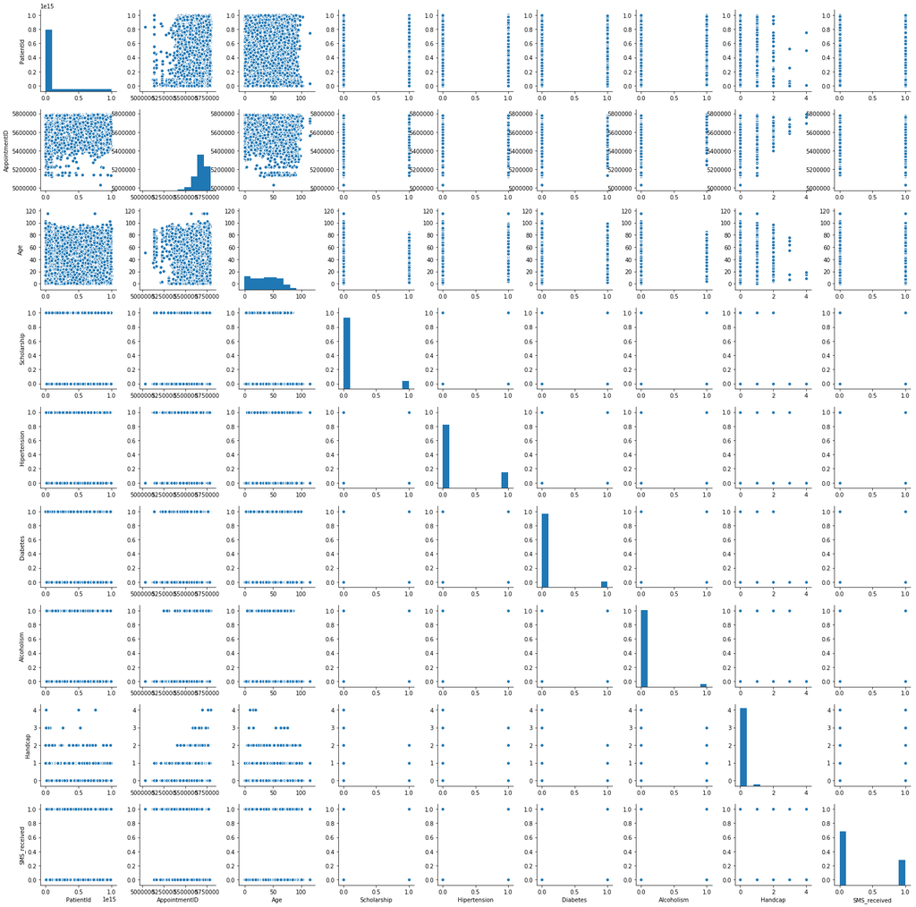

```python
# To Plot pairwise relationships

sns.pairplot(df);
```

**General Observations**:

- The dataset has 14-colums & 110,527-rows and no duplicated values.
- Data type of ScheduledDay and Appointmentday need converted to DateTime.
- No missing values, that so each column has 110,527 values.
- Some column names have `misspellings`.

### Data Cleaning

> Includes
> - Removing any incorrect data for analysis.
> - Checking for error values, NaN in the data and data quality.
> - Converting the (string) Date columns into DateTime type columns.  
>   **Map No_show column**:
> - Normalize No_show column to 0's and 1's -(0) = Showed up -(1) = Did not

```python
# Convert AppointmentDay and ScheduledDay to DateTime format
df.AppointmentDay = df.AppointmentDay.apply(np.datetime64)
df.ScheduledDay   = df.ScheduledDay.apply(np.datetime64)

# raw_data['Mycol'] =  pd.to_datetime(raw_data['Mycol'], format='%d%b%Y:%H:%M:%S.%f')
```

```python
# Rename Columns
df.rename(columns = {'Hipertension': 'Hypertension',
                'Handcap': 'Handicap','No-show':'No_show','PatientId':'PatientID'}, inplace = True)
print(df.columns)
```

```
Index(['PatientID', 'AppointmentID', 'Gender', 'ScheduledDay',
       'AppointmentDay', 'Age', 'Neighbourhood', 'Scholarship', 'Hypertension',
       'Diabetes', 'Alcoholism', 'Handicap', 'SMS_received', 'No_show'],
      dtype='object')
```

```python
# Taking a view of data and checking its quality

print('Age:',sorted(df.Age.unique()))
print('Gender:',df.Gender.unique())
print('Diabetes:',df.Diabetes.unique())
print('Alcoholism:',df.Alcoholism.unique())
print('Hypertension:',df.Hypertension.unique())
print('Handicap:',df.Handicap.unique())
print('Scholarship:',df.Scholarship.unique())
print('SMS Received:',df.SMS_received.unique())
print('No Show:',df.No_show.unique())
```

```
Age: [-1, 0, 1, 2, 3, 4, 5, 6, 7, 8, 9, 10, 11, 12, 13, 14, 15, 16, 17, 18, 19, 20, 21, 22, 23, 24, 25, 26, 27, 28, 29, 30, 31, 32, 33, 34, 35, 36, 37, 38, 39, 40, 41, 42, 43, 44, 45, 46, 47, 48, 49, 50, 51, 52, 53, 54, 55, 56, 57, 58, 59, 60, 61, 62, 63, 64, 65, 66, 67, 68, 69, 70, 71, 72, 73, 74, …
Gender: ['F' 'M']
Diabetes: [0 1]
Alcoholism: [0 1]
Hypertension: [1 0]
Handicap: [0 1 2 3 4]
Scholarship: [0 1]
SMS Received: [0 1]
No Show: ['No' 'Yes']
```

## > As we see above that Age column has data less than 0

```python
(df.Age < 0).sum()
```

```
1
```

```python
df = df[(df.Age >= 0)]
df.shape
```

```
(110526, 14)
```

```python
#Adding the day of Week in the Data Frame

df['WeekDay'] = pd.to_datetime(df['AppointmentDay']).dt.weekday_name
print(sorted(df.WeekDay.unique()));
```

```
['Friday', 'Monday', 'Saturday', 'Thursday', 'Tuesday', 'Wednesday']
```

```python
# Changing data type of 'No_show' column
df['No_show'] = df['No_show'].astype('str',inplace=True)
df['No_show'].replace({'No':0,'Yes':1},inplace=True)
print(df['No_show'].value_counts())
```

```
0    88207
1    22319
Name: No_show, dtype: int64
```

```python
df.info()
```

```
<class 'pandas.core.frame.DataFrame'>
Int64Index: 110526 entries, 0 to 110526
Data columns (total 15 columns):
PatientID         110526 non-null float64
AppointmentID     110526 non-null int64
Gender            110526 non-null object
ScheduledDay      110526 non-null datetime64[ns]
AppointmentDay    110526 non-null datetime64[ns]
Age               110526 non-null int64
Neighbourhood     110526 non-null object
Scholarship       110526 non-null int64
Hypertension      110526 non-null int64
Diabetes          110526 non-null int64
Alcoholism        110526 non-null int64
Handicap          110526 non-null int64
SMS_received      110526 non-null int64
No_show           110526 non-null int64
WeekDay           110526 non-null object
dtypes: datetime64[ns](2), float64(1), int64(9), object(3)
memory usage: 13.5+ MB
```

## Exploratory Data Analysis

### Research Question 1 What is the overall appointment show-up vs. no show-up percentage?

```python
# Total amount of no-show(0) vs. show-up(1)

no_show = df["No_show"].value_counts()
print(no_show)
```

```
0    88207
1    22319
Name: No_show, dtype: int64
```

```python
# Percentage of show and not show
percent_no_show = round(no_show[0]/ no_show.sum() * 100,2)
print("Percentage of people who attend their scheduled appointments:",percent_no_show)
percent_show_up = round(no_show[1]/ no_show.sum() * 100,2)
print("Percentage of people who miss to their scheduled appointments:",percent_show_up)
```

```
Percentage of people who attend their scheduled appointments: 79.81
Percentage of people who miss to their scheduled appointments: 20.19
```

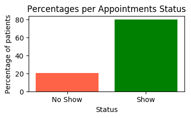

```python
# View bar chart of the percentages

from matplotlib.pyplot import figure

figure(num=None, figsize=(4, 2), dpi=100, facecolor='w', edgecolor='k')
x = ["No Show","Show"]
shows = [percent_show_up, percent_no_show]
colors = ['tomato', 'green']
x_pos = [i for i, _ in enumerate(x)]
plt.bar(x_pos, shows,color = colors)
plt.ylabel("Percentage of patients")
plt.xlabel("Status")
plt.title("Percentages per Appointments Status")
plt.xticks(x_pos, x)
plt.show()
```

### Research Question 2 : Did SMS-reminders decrease the proportion of patients not showing up?

```python
df_sms_received = df[(df['SMS_received'] == 1)]
df_no_sms_received = df[(df['SMS_received'] == 0)]

# Grouping by No-show, to calculate the amounts for each case.
sms_received = df_sms_received.groupby(['No_show']).sum()['SMS_received']

df_no_sms_received.rename(columns={"SMS_received":"SMS_not_received"}, inplace=True)
df_no_sms_received['SMS_not_received'].replace({0: 1}, inplace = True)

no_sms_received = df_no_sms_received.groupby(['No_show']).sum()['SMS_not_received']

# To make sure codes are correct
print(df['AppointmentDay'].count() == sum(sms_received) + sum(no_sms_received))
```

```
True
```

```python
# Total of no-shows depending on receiving SMS remainder messages
print('total no-shows received SMS', sms_received)
print('\n')
print('total no-shows NOT received SMS',no_sms_received)
```

```
total no-shows received SMS No_show
0    25698
1     9784
Name: SMS_received, dtype: int64


total no-shows NOT received SMS No_show
0    62509
1    12535
Name: SMS_not_received, dtype: int64
```

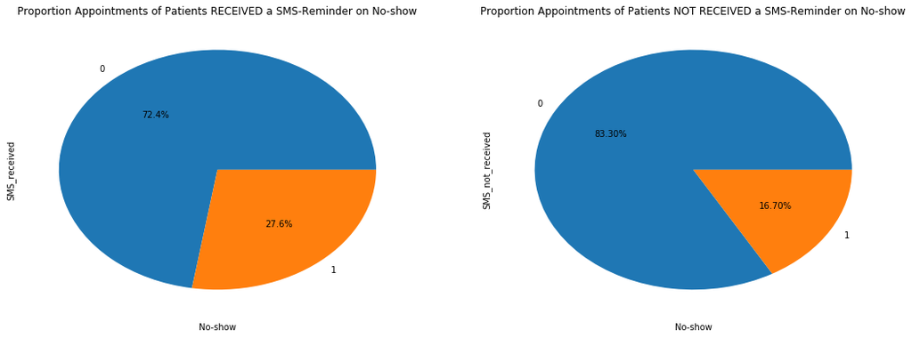

```python
# Making graphs' data
sms_received = sms_received / sum(sms_received) * 100
no_sms_received = no_sms_received / sum(no_sms_received) * 100

# Style and built the graphs
fig = plt.figure(figsize=(18,14))

plt.subplot(2,2,1)
sms_received.plot.pie(autopct='%.1f%%')
plt.title('Proportion Appointments of Patients RECEIVED a SMS-Reminder on No-show')
plt.xlabel('No-show')

plt.subplot(2,2,2)
no_sms_received.plot.pie(autopct='%.2f%%')
plt.title('Proportion Appointments of Patients NOT RECEIVED a SMS-Reminder on No-show')
plt.xlabel('No-show');
```

## Conclusions

To clarify, this analysis is not meant to be providing a final conclusion on the reasons leading to patients missing their appointments as it doesn't involve using any inferential statistics machine learning algorithms; the scope of this project has been customized to meet specific objectives; and the project will be revisited as we progress in the course and utilize more advanced data analysis techniques/algorithms.

The overall **show-up** rate is: **79.81%** ; and **20.19%** who **missed their appointments**

The Show-up rate of patients who **didn't receive an SMS reminder** is the **highest** with **83.3%**, where the show-up rate of patients who **received an SMS reminder** is **72.43%**

```python
from subprocess import call
call(['python', '-m', 'nbconvert', 'Investigate_a_Dataset.ipynb'])
```